# Text Mining

Vishwa

March 8, 2019

## Introduction

The purpose of this assignment is to perform sentiment and lie detection analysis on collection of customer reviews.

## Loading Packages

```r
EnsurePackage <- function(x) {
  x <- as.character(x)
  if (!require(x,character.only = T))
    install.packages(x,repos = "https://cran.cnr.berkeley.edu/")
  require(x,character.only = T)

}

EnsurePackage("caret")# set of functions that attempt to streamline the process for creating predictive models
EnsurePackage("e1071") #Functions for latent class analysis, short time Fourier transform, fuzzy clustering, support vector machines, shortest path computation, bagged clustering, naive Bayes classifier
EnsurePackage("tidyverse") #Manipulating dataset
EnsurePackage("tidytext") #Text mining for word processing and sentiment analysis using 'dplyr', 'ggplot2', and other tidy tools
EnsurePackage("stringr")#Simple, Consistent Wrappers for Common String Operations
EnsurePackage("wordcloud")#wordcloud generator
EnsurePackage("SnowballC")
```

## Loading the file that contains the data

If you look at the excel csv data you will notice that the dataset is improperly organized. The sentences of reviews have been broken into phrases with no header above them. Looking at the excel dataset we can make out that there are 21 columns. So we will use read csv and create new columns till 21. Then we will use R to combine all the columns to create a single review column.

```r
custReview <- read.csv("deception_data_converted_final.csv",stringsAsFactors = F,
                       col.names = c("lie","sentiment","review","1","2","3","4","5","6","7","8","9","10","11","12","13","14","15","16","17","18","19","20","21"))

colnames(custReview) <- c("lie","sentiment","review","1","2","3","4","5","6","7","8","9","10","11","12","13","14","15","16","17","18","19","20","21")

#combining columns review till 21
custReview <- custReview %>%
  unite(reviews,c("review","1","2","3","4","5","6","7","8","9","10","11","12","13","14","15","16","17","18","19","20","21"))
```

## Preprocessing

For preprocessing we will first combine the review columns and then convert the dataset into a document matrix, from which we can then apply machine learning models.First review cell needs to be cleaned.

```r
#Remove rows 83 and 84
custReview <- custReview[-c(83,84),]

#Remove quotes
custReview$reviews <- gsub(x = custReview$reviews, pattern = "\'",replacement = "")

#Remove underscore
custReview$reviews <- gsub(x = custReview$reviews, pattern = "_",replacement = "")
```

## Tokenization

Tokenization is the process of breaking up a text into individual words that form the part of the text. Dplyr functions such as select and unest_tokens was used to get the results

```r
custReview <- rownames_to_column(custReview, "review")

custReview_words <- custReview %>%
  select(review, sentiment, lie, reviews) %>%
  unnest_tokens(word, reviews, to_lower = TRUE) %>% ungroup()
```

## Stemming and lemmatization (Optional)

Stemming is the process of removal of end or beginning of the words to increase the recall by matching words against their shorter form. In our assignment we have used the snowball stemmer. After words were stemmed we noticed that the algorithm removed some words entirely and we were left with NA values. Therefore we removed the rows containing NA values. For this assignment I wont be going ahead with stemming and lemmatization.

```r
# custReview_words$word <- wordStem(custReview_words$word)
# custReview_words <- custReview_words[!is.na(custReview_words$word),]
```

## Visualization

This visualization displays the common words in our dataset

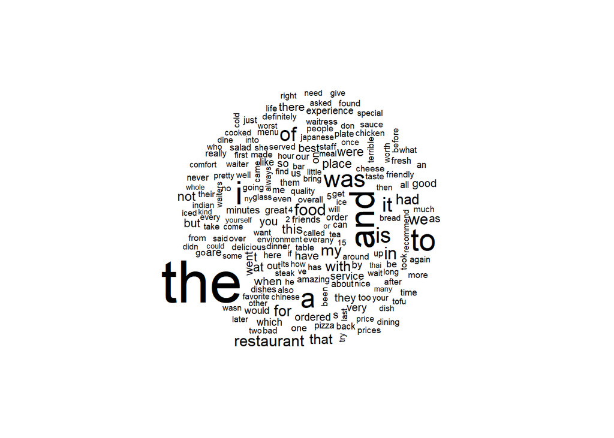

```r
#frequency and word cloud
custReview_words %>%
  count(word) %>%
  with(wordcloud(word, n, max.words = 200))
```

You can see that the visualization is riddled with small words such as prepositions. These are also called stop words and contain little information value, so we will remove these stop words and special characters by importing stop words dataset and using anti_join function

## Stopword removal and visualization

```r
data(stop_words)
custReview_words <- custReview_words %>% anti_join(stop_words)
```

visualizing again

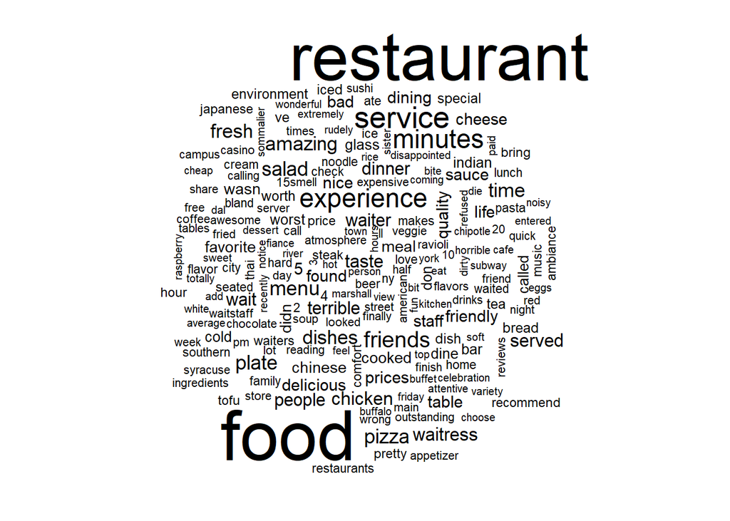

```r
#frequency and word cloud
custReview_words %>%
  count(word) %>%
  with(wordcloud(word, n, max.words = 200))
```

The word cloud looks much better

## Document Term Matrix

We then convert the dataframe into a document term matrix. Document term matrix has words as columns and review no as rows. Each value represents a tf-idf value.

```r
#Construct Document term matrix; tfdif is calculated by function bind_tf_idf
custReview_words_dtm <- custReview_words %>%
  count(review,sentiment,lie, word) %>%
  bind_tf_idf(word, review, n) %>%
  select(review, sentiment,lie, word, tf_idf) %>%
  spread(key = word, value = tf_idf) %>% replace(is.na(.),0)

custReview_words_dtm <- rownames_to_column(custReview_words_dtm, "review_no")
#convert char to factor
custReview_words_dtm <- custReview_words_dtm %>% mutate_at(.vars = c("review_no","sentiment","lie"),function(x) as.factor(x))

#Partition data 80% training
set.seed(8)
sample <- createDataPartition(custReview_words_dtm$sentiment,p = 0.8,times = 1,list=F)
train <-custReview_words_dtm[sample,]
test <- custReview_words_dtm[-sample,]
```

Because of low number of reviews for this assignment I have a hypothesis that we wont be able to get a very good accuracy because the algorithms have very little instances to train from.I also think that sentiment analysis will yeild better accuracy than lie detection because it is difficult for humans to also detect lies and lie detection requires many other metda data besides the reviews eg:user location, user reputation etc. Lets see how training Naive Bayes and SVM goes. ## Performing Naivebayes on sentiment

```r
#preprocessing data, using pca to capture 98% of variability in dataset

trn_full_proc <- preProcess(train,method = c("zv","nzv","pca"),thresh = 0.98)
trn_f <- predict(trn_full_proc,train)

test_f <- predict(trn_full_proc,test)

#10 fold cross validation

fitControl <- trainControl(method='cv',number=10)


start_time <- Sys.time()
nb_senti <- train(sentiment~. -review_no - lie,data = trn_f, trControl = fitControl,method = "nb")
end_time <- Sys.time()
nbtime <- end_time - start_time
nbtime
```

```
## Time difference of 1.262192 secs
```

```r
nb_senti
```

```
## Naive Bayes
##
## 73 samples
## 25 predictors
##  2 classes: 'n', 'p'
##
## No pre-processing
## Resampling: Cross-Validated (10 fold)
## Summary of sample sizes: 66, 65, 65, 67, 66, 66, ...
## Resampling results across tuning parameters:
##
##   usekernel  Accuracy   Kappa
##   FALSE      0.5934524  0.182697
##    TRUE      0.7095238  0.419000
##
## Tuning parameter 'fL' was held constant at a value of 0
## Tuning
##  parameter 'adjust' was held constant at a value of 1
## Accuracy was used to select the optimal model using the largest value.
## The final values used for the model were fL = 0, usekernel = TRUE
##  and adjust = 1.
```

```r
#tuning through laplace

start_time <- Sys.time()
nb_senti_t <- train(sentiment~. -review_no - lie,data = trn_f, trControl = fitControl,method = "nb",tuneGrid = data.frame(fL=c(1),usekernel=c(TRUE), adjust=c(1)))
end_time <- Sys.time()
nbtime2 <- end_time - start_time
nbtime2
```

```
## Time difference of 1.035142 secs
```

```r
nb_senti_t
```

```
## Naive Bayes
##
## 73 samples
## 25 predictors
##  2 classes: 'n', 'p'
##
## No pre-processing
## Resampling: Cross-Validated (10 fold)
## Summary of sample sizes: 66, 65, 65, 66, 66, 65, ...
## Resampling results:
##
##   Accuracy   Kappa
##   0.7244048  0.4520717
##
## Tuning parameter 'fL' was held constant at a value of 1
## Tuning
##  parameter 'usekernel' was held constant at a value of TRUE
##
## Tuning parameter 'adjust' was held constant at a value of 1
```

```r
#accuracy did improve so we will use tuned parameter for final model

#prediction
predict_nb <- predict(nb_senti_t,newdata = test_f)

metrics <- confusionMatrix(predict_nb, test_f$sentiment)


nbSentiAccuracy <-  metrics$overall[1]
nbprecision <- metrics$byClass[5]
nbrecall <- metrics$byClass[6]
```

## Performing SVM on sentiment

```r
start_time <- Sys.time()
svm_senti <- train(sentiment~. -review_no - lie,data = trn_f, trControl = fitControl,method = "svmRadial",tuneLength = 10)
end_time <- Sys.time()
svmtime <- end_time - start_time
svmtime
```

```
## Time difference of 2.428671 secs
```

```r
svm_senti
```

```
## Support Vector Machines with Radial Basis Function Kernel
##
## 73 samples
## 25 predictors
##  2 classes: 'n', 'p'
##
## No pre-processing
## Resampling: Cross-Validated (10 fold)
## Summary of sample sizes: 65, 65, 66, 66, 65, 66, ...
## Resampling results across tuning parameters:
##
##   C       Accuracy   Kappa
##     0.25  0.5357143  0.09772727
##     0.50  0.5107143  0.02838164
##     1.00  0.6214286  0.21732279
##     2.00  0.6589286  0.29475758
##     4.00  0.6714286  0.31975758
##     8.00  0.6428571  0.26442161
##    16.00  0.6857143  0.34578393
##    32.00  0.7071429  0.39275362
##    64.00  0.7071429  0.39275362
##   128.00  0.7071429  0.39275362
##
## Tuning parameter 'sigma' was held constant at a value of 0.02523281
## Accuracy was used to select the optimal model using the largest value.
## The final values used for the model were sigma = 0.02523281 and C = 32.
```

```r
# Creating A tuned train model out of results obtained from previous model
start_time <- Sys.time()
svm_senti_f <- train(sentiment~. -review_no - lie,data = trn_f, trControl = fitControl,method = "svmRadial", tuneGrid = data.frame(C=c(32),sigma=0.02))
end_time <- Sys.time()
svmtime <- end_time - start_time
svmtime
```

```
## Time difference of 0.5649102 secs
```

```r
svm_senti_f
```

```
## Support Vector Machines with Radial Basis Function Kernel
##
## 73 samples
## 25 predictors
##  2 classes: 'n', 'p'
##
## No pre-processing
## Resampling: Cross-Validated (10 fold)
## Summary of sample sizes: 66, 66, 66, 65, 65, 66, ...
## Resampling results:
##
##   Accuracy   Kappa
##   0.6892857  0.3689799
##
## Tuning parameter 'sigma' was held constant at a value of 0.02
##
## Tuning parameter 'C' was held constant at a value of 32
```

```r
#final prediction and confusion matrix
#prediction
predict_svm <- predict(svm_senti_f,newdata = test_f)

metrics_svm <- confusionMatrix(predict_svm, test_f$sentiment)
metrics_svm
```

```
## Confusion Matrix and Statistics
##
##           Reference
## Prediction n p
##          n 8 2
##          p 1 6
##
##                Accuracy : 0.8235
##                  95% CI : (0.5657, 0.962)
##     No Information Rate : 0.5294
##     P-Value [Acc > NIR] : 0.01212
##
##                   Kappa : 0.6434
##  Mcnemar's Test P-Value : 1.00000
##
##             Sensitivity : 0.8889
##             Specificity : 0.7500
##          Pos Pred Value : 0.8000
##          Neg Pred Value : 0.8571
##              Prevalence : 0.5294
##          Detection Rate : 0.4706
##    Detection Prevalence : 0.5882
##       Balanced Accuracy : 0.8194
##
##        'Positive' Class : n
##
```

```r
svmSentiAccuracy <-  metrics_svm$overall[1]
svmprecision <- metrics_svm$byClass[5]
svmrecall <- metrics_svm$byClass[6]
```

## Performing NB on lie detection

```r
start_time <- Sys.time()
nb_lie_t <- train(lie~. -review_no - sentiment,data = trn_f, trControl = fitControl,method = "nb",tuneGrid = data.frame(fL=c(1),usekernel=c(TRUE), adjust=c(1)))
end_time <- Sys.time()
nbtimelie <- end_time - start_time
nbtimelie
```

```
## Time difference of 0.9953592 secs
```

```r
nb_lie_t
```

```
## Naive Bayes
##
## 73 samples
## 25 predictors
##  2 classes: 'f', 't'
##
## No pre-processing
## Resampling: Cross-Validated (10 fold)
## Summary of sample sizes: 66, 66, 66, 66, 66, 65, ...
## Resampling results:
##
##   Accuracy  Kappa
##   0.55      0.08123935
##
## Tuning parameter 'fL' was held constant at a value of 1
## Tuning
##  parameter 'usekernel' was held constant at a value of TRUE
##
## Tuning parameter 'adjust' was held constant at a value of 1
```

```r
#prediction
predict_nb_lie <- predict(nb_lie_t,newdata = test_f)

metrics_lie <- confusionMatrix(predict_nb_lie, test_f$lie)

nbLieAccuracy <-  metrics_lie$overall[1]
nbLieprecision <- metrics_lie$byClass[5]
nbLierecall <- metrics_lie$byClass[6]
metrics_lie
```

```
## Confusion Matrix and Statistics
##
##           Reference
## Prediction f t
##          f 3 7
##          t 3 4
##
##                Accuracy : 0.4118
##                  95% CI : (0.1844, 0.6708)
##     No Information Rate : 0.6471
##     P-Value [Acc > NIR] : 0.9871
##
##                   Kappa : -0.1184
##  Mcnemar's Test P-Value : 0.3428
##
##             Sensitivity : 0.5000
##             Specificity : 0.3636
##          Pos Pred Value : 0.3000
##          Neg Pred Value : 0.5714
##              Prevalence : 0.3529
##          Detection Rate : 0.1765
##    Detection Prevalence : 0.5882
##       Balanced Accuracy : 0.4318
##
##        'Positive' Class : f
##
```

## Performing SVM on lie detection

```r
start_time <- Sys.time()
svm_lie_f <- train(lie~. -review_no - sentiment,data = trn_f, trControl = fitControl,method = "svmRadial", tuneGrid = data.frame(C=c(32),sigma=0.02))
end_time <- Sys.time()
svmtimelie <- end_time - start_time
svmtimelie
```

```
## Time difference of 0.536639 secs
```

```r
svm_lie_f
```

```
## Support Vector Machines with Radial Basis Function Kernel
##
## 73 samples
## 25 predictors
##  2 classes: 'f', 't'
##
## No pre-processing
## Resampling: Cross-Validated (10 fold)
## Summary of sample sizes: 66, 66, 66, 66, 66, 65, ...
## Resampling results:
##
##   Accuracy   Kappa
##   0.3517857  -0.2770415
##
## Tuning parameter 'sigma' was held constant at a value of 0.02
##
## Tuning parameter 'C' was held constant at a value of 32
```

```r
predict_svm_lie <- predict(svm_lie_f,newdata = test_f)

metrics_svm_lie <- confusionMatrix(predict_svm_lie, test_f$lie)
metrics_svm_lie
```

```
## Confusion Matrix and Statistics
##
##           Reference
## Prediction f t
##          f 4 6
##          t 2 5
##
##                Accuracy : 0.5294
##                  95% CI : (0.2781, 0.7702)
##     No Information Rate : 0.6471
##     P-Value [Acc > NIR] : 0.8959
##
##                   Kappa : 0.1053
##  Mcnemar's Test P-Value : 0.2888
##
##             Sensitivity : 0.6667
##             Specificity : 0.4545
##          Pos Pred Value : 0.4000
##          Neg Pred Value : 0.7143
##              Prevalence : 0.3529
##          Detection Rate : 0.2353
##    Detection Prevalence : 0.5882
##       Balanced Accuracy : 0.5606
##
##        'Positive' Class : f
##
```

```r
svmLieAccuracy <- metrics_svm_lie$overall[1]
svmLieprecision <- metrics_svm_lie$byClass[5]
svmLierecall <- metrics_svm_lie$byClass[6]
```

```r
ab <- data.frame("Algorithm" = c("Naive Bayes","SVM"), "Parameter Setting" = c("fL=1, Kernel=TRUE,adjust(1)","C=32,sigma=0.02"),"Accuracy Sentiment" = c(nbSentiAccuracy
,svmSentiAccuracy),
                 "Accuracy Lie" = c(nbLieAccuracy,svmLieAccuracy),"Precision Cat 1" = c(nbprecision,svmprecision
),
                 "Recall Cat 1" = c(nbrecall,svmrecall
),"Precision Cat 2" = c(nbLieprecision
,svmLieprecision
),"Recall Cat 2" = c(nbLierecall,svmLierecall))

{knitr::kable(ab)}
```

| Algorithm | Parameter.Setting | Accuracy.Sentiment | Accuracy.Lie | Precision.Cat.1 | Recall.Cat.1 | Precision.Cat.2 | Recall.Cat.2 |
| --- | --- | --- | --- | --- | --- | --- | --- |
| Naive Bayes | fL=1, Kernel=TRUE,adjust(1) | 0.7058824 | 0.4117647 | 0.6666667 | 0.8888889 | 0.3 | 0.5000000 |
| SVM | C=32,sigma=0.02 | 0.8235294 | 0.5294118 | 0.8000000 | 0.8888889 | 0.4 | 0.6666667 |

## Conclusion

As predicted sentiment analysis gave us better accuracy than lie detection. This is because detecting lie requires many more meta data such as location, user reputation, fact checks(whether restaurant servers the dish the user is complaining about) etc. I was surprised to see we achieved a good accuracy on Naive Bayes and SVM for sentiment analysis. Reference:https://www.tidytextmining.com/tidytext.html